# DATA 643: Recommender Systems

Project 1

Walt Wells, Summer 2017

## Overview

- Briefly describe the recommender system that you’re going to build out from a business perspective, e.g. “This system recommends data science books to readers.”

**We’ll just generate some toy data at this stage to learn the concepts behind building a system. Our toy data will match User_[i] with Item_[j] based on a 1 to 5 rating system.**

## Data Prep

- Find a dataset, or build out your own toy dataset. As a minimum requirement for complexity, please include numeric ratings for at least five users, across at least five items, with some missing data.
- Load your data into (for example) an R or pandas dataframe, a Python dictionary or list of lists, (or another data structure of your choosing). From there, create a user-item matrix.

```r
# randomly create a toy square matrix with n users and items, ranking 1 to 5
# in the code below, n cannot be > 27 because english alphabet ;)

# set simulation vars
set.seed(643)
n <- 15
percentNAs <- .3
probs <- c(1-percentNAs, percentNAs)
users <- paste("User_", LETTERS[1:n], sep="")
items <- paste("Item_", LETTERS[1:n], sep="")

# generate data
toyDF <- as.data.frame(replicate(n, floor(runif(n, 1,6))))

## Test introducing item bias (see summary)
#toyDF[,1:3] <- toyDF[,1:3] + 1
#toyDF[,4:6] <- toyDF[,4:6] - 1
#toyDF[toyDF > 5] <- 5
#toyDF[toyDF < 1] <- 1

# add NAs via: https://stackoverflow.com/questions/27454265/r-randomly-insert-nas-into-dataframe-proportionaly
toyDF <- as.data.frame(
    lapply(toyDF, function(df) df[sample(c(TRUE, NA), prob = probs, size = length(df), replace = TRUE) ]),
    row.names = users,
    col.names = items)

knitr::kable(toyDF)
```

|  | Item_A | Item_B | Item_C | Item_D | Item_E | Item_F | Item_G | Item_H | Item_I | Item_J | Item_K | Item_L | Item_M | Item_N | Item_O |
| --- | --- | --- | --- | --- | --- | --- | --- | --- | --- | --- | --- | --- | --- | --- | --- |
| User_A | 5 | 4 | 4 | 2 | 2 | NA | 4 | NA | NA | 5 | NA | 2 | 5 | 2 | 2 |
| User_B | NA | 3 | 5 | 3 | 1 | 5 | 3 | 1 | NA | 5 | 4 | NA | NA | 5 | 2 |
| User_C | NA | 1 | 3 | 1 | 1 | 3 | 4 | 3 | NA | 5 | NA | NA | 4 | 2 | 3 |
| User_D | NA | 1 | 1 | 2 | NA | 4 | NA | 4 | 4 | NA | 3 | 4 | NA | 1 | 4 |
| User_E | 3 | NA | 5 | NA | 1 | 5 | 5 | 2 | 3 | 1 | 2 | 2 | NA | NA | 1 |
| User_F | NA | 4 | 5 | 3 | 3 | 5 | 2 | 4 | 3 | 1 | 4 | 4 | 1 | 5 | NA |
| User_G | 4 | 5 | 5 | 5 | 2 | 4 | NA | NA | NA | 2 | 1 | NA | NA | 5 | 3 |
| User_H | 5 | NA | NA | 2 | 1 | 5 | 5 | 3 | 1 | 3 | 5 | NA | NA | 4 | 1 |
| User_I | 2 | NA | 1 | 1 | 1 | NA | NA | 5 | 5 | 1 | NA | 2 | 3 | 1 | 5 |
| User_J | 5 | 4 | NA | 4 | 4 | NA | 2 | NA | 1 | NA | 3 | NA | 4 | 4 | 5 |
| User_K | NA | 4 | 4 | 3 | NA | NA | 4 | NA | NA | NA | 1 | 5 | NA | NA | 1 |
| User_L | 1 | 2 | 3 | 5 | 3 | 4 | NA | 3 | 4 | 3 | 3 | 1 | 3 | 1 | NA |
| User_M | NA | 5 | 1 | 3 | 3 | 5 | 1 | NA | NA | 2 | NA | 2 | 2 | 1 | 4 |
| User_N | 2 | 5 | NA | 1 | 3 | 4 | 1 | 1 | 1 | NA | 5 | 3 | NA | 2 | 5 |
| User_O | 5 | 1 | 5 | 3 | NA | 1 | 5 | 1 | 1 | NA | 1 | NA | 5 | NA | NA |

## Data Visualization

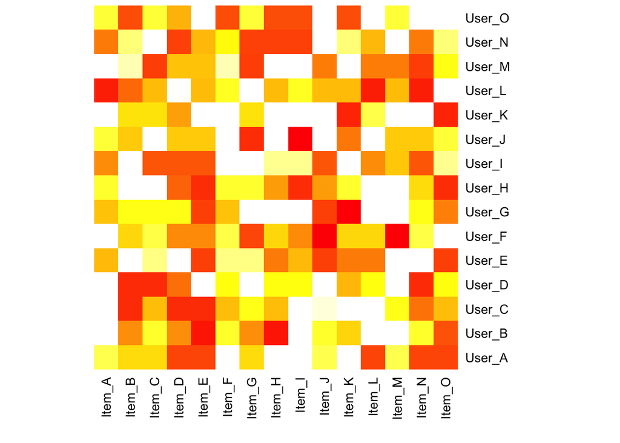

```r
heatmap(as.matrix(toyDF), Rowv=NA, Colv=NA, col = heat.colors(256))
```

## Separate Data

- If you choose to work with a large dataset, you’re encouraged to also create a small, relatively dense “user-item” matrix as a subset so that you can hand-verify your calculations.
- Break your ratings into separate training and test datasets

```r
# THIS IS WRONG - Out of time to find an elegant solution to sample for RecSys
# so that train and test have the same dimensions AND ensure proper distribution
# eg - userA only rates 1 movie, make sure it ends up in 'train'.   Look forward
# to seeing how others have solved this.

train_row <- sample(n, size = floor(2/3 * n), replace=F)
train <- toyDF[train_row, ]
test <- toyDF[-train_row, ]
```

## Calculations

- Using your training data, calculate the raw average (mean) rating for every user-item combination

```r
train_raw_avg <- mean(as.matrix(train), na.rm=TRUE)
train_raw_avg
```

```
## [1] 3.019048
```

- Calculate the RMSE for raw average for both your training data and your test data.

```r
RMSE <- function(observed, predicted) {
    # get RMSE
    sqrt(mean((observed - predicted)^2, na.rm=TRUE))
}

trainRMSE <- RMSE(as.matrix(train), train_raw_avg)
trainRMSE
```

```
## [1] 1.492719
```

```r
testRMSE <- RMSE(as.matrix(test), train_raw_avg)
testRMSE
```

```
## [1] 1.521891
```

- Using your training data, calculate the bias for each user and each item.

```r
user_bias_train <- rowMeans(as.matrix(train), na.rm = T) - train_raw_avg
user_bias_test <- rowMeans(as.matrix(test), na.rm = T) - train_raw_avg
item_bias_train <- colMeans(as.matrix(train), na.rm = T) - train_raw_avg
user_bias_train
```

```
##     User_J     User_K     User_H     User_G     User_C     User_E
##  0.5809524  0.1238095  0.1627706  0.5809524 -0.2917749 -0.2917749
##     User_F     User_D     User_M     User_I
##  0.3655678 -0.2190476 -0.3826840 -0.5645022
```

```r
user_bias_test
```

```
##     User_A     User_B     User_L     User_N     User_O
##  0.3445887  0.3445887 -0.2498168 -0.2690476 -0.2190476
```

```r
item_bias_train
```

```
##      Item_A      Item_B      Item_C      Item_D      Item_E      Item_F
##  0.78095238  0.40952381  0.10595238 -0.35238095 -1.01904762  1.40952381
##      Item_G      Item_H      Item_I      Item_J      Item_K      Item_L
##  0.26666667  0.48095238 -0.18571429 -0.87619048 -0.30476190  0.14761905
##      Item_M      Item_N      Item_O
## -0.21904762 -0.14404762 -0.01904762
```

- From the raw average, and the appropriate user and item biases, calculate the baseline predictors for every user-item combination.

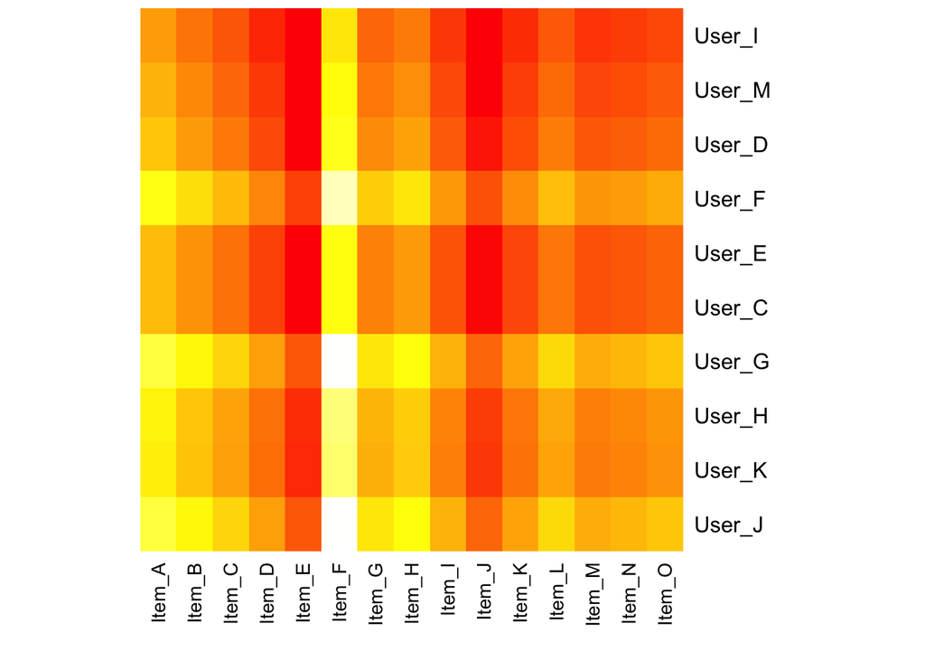

```r
baseline_predictor <- function(rawAvg, userBias, itemBias) {
    # calculates predictions based on rawaverage and user and item bias calcs
    userlist <- names(userBias)
    itemlist <- names(itemBias)
    df <- data.frame()

    for (i in userBias) {
        UserPred <- rawAvg + i + itemBias
        df <- rbind(df, UserPred)
    }

    # make sure we don't exceed our max and min values
    df[df > 5] <- 5
    df[df < 1] <- 1

    row.names(df) <- userlist
    names(df) <- itemlist
    df
}

trainPredictions <- baseline_predictor(train_raw_avg, user_bias_train, item_bias_train)
heatmap(as.matrix(trainPredictions), Rowv=NA, Colv=NA, scale = 'none', col = heat.colors(256))
```

```r
knitr::kable(trainPredictions)
```

|  | Item_A | Item_B | Item_C | Item_D | Item_E | Item_F | Item_G | Item_H | Item_I | Item_J | Item_K | Item_L | Item_M | Item_N | Item_O |
| --- | --- | --- | --- | --- | --- | --- | --- | --- | --- | --- | --- | --- | --- | --- | --- |
| User_J | 4.380952 | 4.009524 | 3.705952 | 3.247619 | 2.580952 | 5.000000 | 3.866667 | 4.080952 | 3.414286 | 2.723810 | 3.295238 | 3.747619 | 3.380952 | 3.455952 | 3.580952 |
| User_K | 3.923809 | 3.552381 | 3.248810 | 2.790476 | 2.123810 | 4.552381 | 3.409524 | 3.623810 | 2.957143 | 2.266667 | 2.838095 | 3.290476 | 2.923809 | 2.998810 | 3.123810 |
| User_H | 3.962771 | 3.591342 | 3.287771 | 2.829437 | 2.162771 | 4.591342 | 3.448485 | 3.662771 | 2.996104 | 2.305628 | 2.877056 | 3.329437 | 2.962771 | 3.037771 | 3.162771 |
| User_G | 4.380952 | 4.009524 | 3.705952 | 3.247619 | 2.580952 | 5.000000 | 3.866667 | 4.080952 | 3.414286 | 2.723810 | 3.295238 | 3.747619 | 3.380952 | 3.455952 | 3.580952 |
| User_C | 3.508225 | 3.136796 | 2.833225 | 2.374892 | 1.708225 | 4.136796 | 2.993939 | 3.208225 | 2.541558 | 1.851082 | 2.422511 | 2.874892 | 2.508225 | 2.583225 | 2.708225 |
| User_E | 3.508225 | 3.136796 | 2.833225 | 2.374892 | 1.708225 | 4.136796 | 2.993939 | 3.208225 | 2.541558 | 1.851082 | 2.422511 | 2.874892 | 2.508225 | 2.583225 | 2.708225 |
| User_F | 4.165568 | 3.794139 | 3.490568 | 3.032234 | 2.365568 | 4.794139 | 3.651282 | 3.865568 | 3.198901 | 2.508425 | 3.079854 | 3.532234 | 3.165568 | 3.240568 | 3.365568 |
| User_D | 3.580952 | 3.209524 | 2.905952 | 2.447619 | 1.780952 | 4.209524 | 3.066667 | 3.280952 | 2.614286 | 1.923809 | 2.495238 | 2.947619 | 2.580952 | 2.655952 | 2.780952 |
| User_M | 3.417316 | 3.045887 | 2.742316 | 2.283983 | 1.617316 | 4.045887 | 2.903030 | 3.117316 | 2.450649 | 1.760173 | 2.331602 | 2.783983 | 2.417316 | 2.492316 | 2.617316 |
| User_I | 3.235498 | 2.864069 | 2.560498 | 2.102165 | 1.435498 | 3.864069 | 2.721212 | 2.935498 | 2.268831 | 1.578355 | 2.149783 | 2.602165 | 2.235498 | 2.310498 | 2.435498 |

```r
testPredictions <- baseline_predictor(train_raw_avg, user_bias_test, item_bias_train)
knitr::kable(testPredictions)
```

|  | Item_A | Item_B | Item_C | Item_D | Item_E | Item_F | Item_G | Item_H | Item_I | Item_J | Item_K | Item_L | Item_M | Item_N | Item_O |
| --- | --- | --- | --- | --- | --- | --- | --- | --- | --- | --- | --- | --- | --- | --- | --- |
| User_A | 4.144589 | 3.773160 | 3.469589 | 3.011255 | 2.344589 | 4.773160 | 3.630303 | 3.844589 | 3.177922 | 2.487446 | 3.058874 | 3.511255 | 3.144589 | 3.219589 | 3.344589 |
| User_B | 4.144589 | 3.773160 | 3.469589 | 3.011255 | 2.344589 | 4.773160 | 3.630303 | 3.844589 | 3.177922 | 2.487446 | 3.058874 | 3.511255 | 3.144589 | 3.219589 | 3.344589 |
| User_L | 3.550183 | 3.178755 | 2.875183 | 2.416850 | 1.750183 | 4.178755 | 3.035897 | 3.250183 | 2.583516 | 1.893040 | 2.464469 | 2.916850 | 2.550183 | 2.625183 | 2.750183 |
| User_N | 3.530952 | 3.159524 | 2.855952 | 2.397619 | 1.730952 | 4.159524 | 3.016667 | 3.230952 | 2.564286 | 1.873809 | 2.445238 | 2.897619 | 2.530952 | 2.605952 | 2.730952 |
| User_O | 3.580952 | 3.209524 | 2.905952 | 2.447619 | 1.780952 | 4.209524 | 3.066667 | 3.280952 | 2.614286 | 1.923809 | 2.495238 | 2.947619 | 2.580952 | 2.655952 | 2.780952 |

- Calculate the RMSE for the baseline predictors for both your training data and your test data.

```r
trainPredictionRSME <- RMSE(as.matrix(train), as.matrix(trainPredictions))
trainPredictionRSME
```

```
## [1] 1.312058
```

```r
testPredictionRSME <- RMSE(as.matrix(test), as.matrix(testPredictions))
testPredictionRSME
```

```
## [1] 1.588344
```

## Summary

- Summarize your results.

```r
trainVec <- c(trainRMSE,
              trainPredictionRSME,
              (1-trainPredictionRSME/trainRMSE)*100)
testVec <- c(testRMSE,
             testPredictionRSME,
             (1-testPredictionRSME/testRMSE)*100)
summary <- data.frame(trainVec, testVec)
names(summary) <- c("train", "test")
row.names(summary) <- c("Raw Average RMSE",
                       "Simple Predictor RMSE",
                       "Percent Improvement")
knitr::kable(summary)
```

|  | train | test |
| --- | --- | --- |
| Raw Average RMSE | 1.492719 | 1.521891 |
| Simple Predictor RMSE | 1.312058 | 1.588344 |
| Percent Improvement | 12.102785 | -4.366478 |

Our percent improvement actually decreased over the test data, while improving over the training data. If I am intepreting this correctly, this is because we used randomly generated data so there are no obviously inherent biases in the test set - thus the training biases for items applied to the test data did not improve performance. But we can see that since these biases are fit to the training data, they did actually improve the RMSE in the training set.

I attempted to introduce some simple item bias to the the randomly generated data by manually increasing and decreasing the average ratings (see lines #38-42 commented out in the first code block). When this bias was introduced, and the rest of the code run, we can see slight improvements in the test RMSE.

Similarly, with more data (obtained by increasing “n” or decreasing matrix sparseness via the “percentNA” variable), we also see improvements in our predictor’s performance.

# References

- https://www.youtube.com/playlist?list=PLuKhJYywjDe96T2L0-zXFU5Up2jqXlWI9
- https://stackoverflow.com/questions/27454265/r-randomly-insert-nas-into-dataframe-proportionaly
- [Building a Recommendation System with Rby Suresh K. Gorakala, Michele Usuelli](https://www.amazon.com/dp/B012O8S1YM/ref=dp-kindle-redirect?_encoding=UTF8&btkr=1)